# 感知机

2026-11-5

课程代码均在如下 GitHub 仓库开源：https://github.com/GHe0000/xmu_machine_learning

项目自动生成网页地址：https://ghe0000.github.io/xmu_machine_learning

## 目录

- 作业要求
- 背景补充
  - 感知机
- 数据集生成和划分
  - 数据生成
  - 数据划分
- 多项式 Feature Mapping 方法
  - 多项式 Feature Mapping 和特征标准化
  - 模型定义
  - 模型训练
  - 多项式阶数扫描
  - 最优模型
- 核方法
  - 特征标准化
  - 模型定义
  - 模型训练
  - Gamma 扫描
  - 最优模型
- 结论
- 参考资料以及 AI 使用说明
- 致谢
- 附一：问题
  - 随机梯度下降与郎之万方程关系？
  - 随机梯度下降过程中的波动与 Loss 函数或模型的某些性质的关系？
- 附二：学习心得

## 作业要求

手动编程完成：用“多项式 feature mapping + 感知机算法”和 “核方法+感知机算法” 完成 moon 数据集的分类任务.

## 背景补充

### 感知机

感知机通过线性组合和阈值函数完成分类，并根据预测结果与真实标签之间的误差不断修正模型参数.

对于输入特征向量 $\mathbf x\in\mathbb R^d$，感知机首先计算

$$ s(\mathbf x)=\mathbf w^\mathsf T\mathbf x+b $$

其中 $\mathbf w$ 为权重向量，$b$ 为偏置. 随后使用符号函数进行分类：

$$ \hat t= \begin{cases} 1,&s(\mathbf x)\geq0\\ -1,&s(\mathbf x)<0 \end{cases} $$

因此，感知机对应的分类边界为

$$ \mathbf w^\mathsf T\mathbf x+b=0 $$

感知机对于真实标签 $t_i\in\{-1,1\}$，定义分类误差 $e_i=t_i-\hat t_i$，由于真实标签和预测标签均为 $\pm1$，因此 $e_i\in\{-2,0,2\}$. 感知机的参数更新可以写为

$$ \begin{aligned} \mathbf w^{\mathrm{new}}&=\mathbf w^{\mathrm{old}}+\frac12e_i\mathbf x_i\\ b^{\mathrm{new}}&=b^{\mathrm{old}}+\frac12e_i \end{aligned} $$

我们也可以从随机次梯度下降的角度给出参数更新公式. 定义感知机损失函数

$$ L_i(\mathbf w,b)=\max\left(0,-t_i(\mathbf w^\mathsf T\mathbf x_i+b)\right) $$

当 $t_i s(\mathbf x_i)<0$ 时，样本被错误分类，此时

$$ \begin{aligned} \nabla_{\mathbf w}L_i&=-t_i\mathbf x_i\\ \frac{\partial L_i}{\partial b}&=-t_i \end{aligned} $$

使用步长为 $1$ 的随机次梯度更新，得到

$$ \begin{aligned} \mathbf w^{\mathrm{new}}&=\mathbf w^{\mathrm{old}}+t_i\mathbf x_i\\ b^{\mathrm{new}}&=b^{\mathrm{old}}+t_i \end{aligned} $$

这与前面的参数更新规则相同.

## 数据集生成和划分

导入需要的库，并针对 Jupyter Notebook 进行一些设置.

```python
import numpy as np # 数值计算库
import numba as nb # 引入 jit 来加速函数（如果需要）
import sympy as sym # 符号计算库
import matplotlib as mpl
import matplotlib.pyplot as plt # 图像绘制
from matplotlib.backends.backend_agg import FigureCanvasAgg # 设置图像后端用
import ipywidgets as ipw # 交互控件
from IPython.display import display, Math, Latex # 打印数学公式
import time
import tracemalloc

import pandas as pd

from io import BytesIO
import matplotlib.animation as animation # 创建动画
from IPython.display import HTML # 动画嵌入
import scipy

from sklearn.datasets import make_moons, make_blobs, make_circles, make_classification

# 使用 mathjax 来在 jupyter notebook 显示数学公式
sym.init_printing(use_latex='mathjax')

# 设置 matplotlib 绘制的图像嵌入到 jupyter notebook 的方式
%matplotlib widget

# 一个工具函数，可以让静态图片不经过 widget 直接嵌入 Jupyter notebook
# 这样图片可以直接存到 nb 文件里，而不是需要运行才能显示（类似 inline）
def display_inline(fig):
    try:
        try:
            fig.canvas.draw()
            fig.canvas.flush_events()
        except Exception:
            pass

        fig.set_canvas(FigureCanvasAgg(fig))
        try:
            import matplotlib.text as mtext

            if hasattr(mtext, "_get_text_metrics_with_cache_impl"):
                mtext._get_text_metrics_with_cache_impl.cache_clear()
        except Exception:
            pass
        try:
            fig.draw_without_rendering()
        except Exception:
            pass
        fig.tight_layout()
        fig.canvas.draw()
        display(fig)

    finally:
        plt.close(fig)  # 释放 fig，减小资源消耗

# 一个工具函数，用于在 Jupyter 中快速实现公式和字符串混合输出
def display_math(*args):
    parts = []
    for a in args:
        if isinstance(a, str):
            parts.append(a)
        else:
            parts.append(sym.latex(a))
    display(Math("".join(parts)))

# 设置 matplotlib 使用的字体，避免出现中文问题
plt.rcParams.update({
    # 字体
    "font.family": ["SimSun", "Times New Roman"],
    "font.size": 14,
    "mathtext.fontset": "cm",
    "axes.unicode_minus": False,

    # 字号
    "axes.titlesize": 14,
    "axes.labelsize": 14,
    "xtick.labelsize": 14,
    "ytick.labelsize": 14,
    "legend.fontsize": 14,
    "figure.titlesize": 14,
})

# 设置种子，保证可重复性
rng = np.random.default_rng(3407)
```

### 数据生成

根据作业要求，这里我们直接复用之前作业的生成 Moon 数据集的代码：

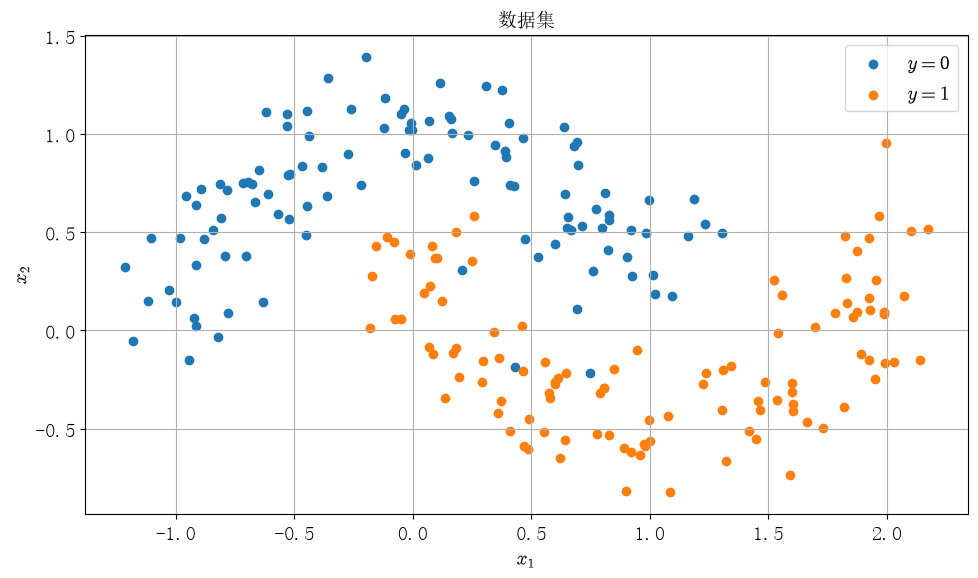

```python
X, y = make_moons(n_samples=220, noise=0.18, random_state=44)

fig, ax = plt.subplots(figsize=(10, 6))
ax.scatter(X[y == 0, 0], X[y == 0, 1], label="$y=0$")
ax.scatter(X[y == 1, 0], X[y == 1, 1], label="$y=1$")
ax.set(xlabel="$x_1$", ylabel="$x_2$", title="数据集")
ax.grid(True); ax.legend()
display_inline(fig)
```

### 数据划分

按 6:2:2 划分训练、验证、测试三个集合.

```python
rng = np.random.default_rng(3407)

idx_0 = np.where(y == 0)[0]
idx_1 = np.where(y == 1)[0]

rng.shuffle(idx_0)
rng.shuffle(idx_1)

n_0 = len(idx_0)
n_1 = len(idx_1)

n_0_train = int(0.6 * n_0)
n_0_val = int(0.2 * n_0)

n_1_train = int(0.6 * n_1)
n_1_val = int(0.2 * n_1)

idx_0_train = idx_0[:n_0_train]
idx_0_val = idx_0[n_0_train:n_0_train + n_0_val]
idx_0_test = idx_0[n_0_train + n_0_val:]

idx_1_train = idx_1[:n_1_train]
idx_1_val = idx_1[n_1_train:n_1_train + n_1_val]
idx_1_test = idx_1[n_1_train + n_1_val:]

idx_train = np.concatenate((idx_0_train, idx_1_train))
idx_val = np.concatenate((idx_0_val, idx_1_val))
idx_test = np.concatenate((idx_0_test, idx_1_test))

rng.shuffle(idx_train)
rng.shuffle(idx_val)
rng.shuffle(idx_test)

X_train, y_train = X[idx_train].copy(), y[idx_train].copy()
X_val, y_val = X[idx_val].copy(), y[idx_val].copy()
X_test, y_test = X[idx_test].copy(), y[idx_test].copy()

print("训练集：", X_train.shape)
print("验证集：", X_val.shape)
print("测试集：", X_test.shape)
```

```
训练集： (132, 2)
验证集： (44, 2)
测试集： (44, 2)
```

绘制分类后的数据集.

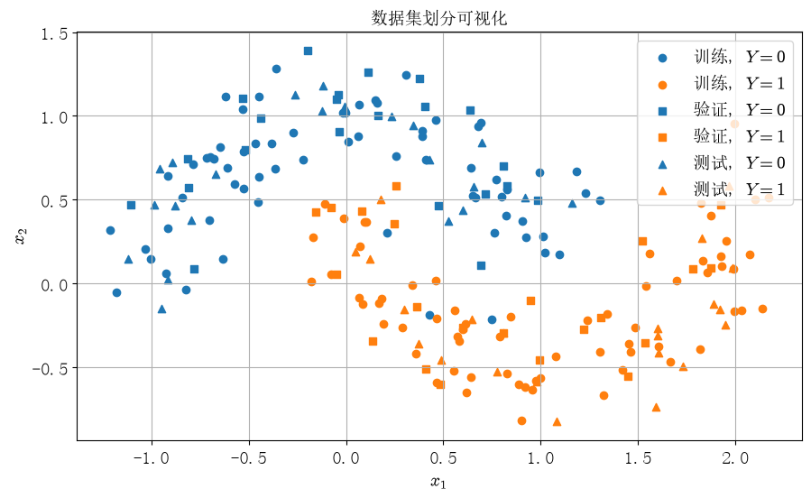

```python
fig, ax = plt.subplots(figsize=(10, 6))

for X_part, y_part, marker, name in [
    (X_train, y_train, "o", "训练"),
    (X_val, y_val, "s", "验证"),
    (X_test, y_test, "^", "测试")
]:
    ax.scatter(
        X_part[y_part == 0, 0], X_part[y_part == 0, 1],
        c="C0", marker=marker, label=fr"{name}, $Y=0$"
    )
    ax.scatter(
        X_part[y_part == 1, 0], X_part[y_part == 1, 1],
        c="C1", marker=marker, label=fr"{name}, $Y=1$"
    )

ax.set_xlabel(r"$x_1$")
ax.set_ylabel(r"$x_2$")
ax.set_title("数据集划分可视化")
ax.grid(True)
ax.legend()

display_inline(fig)
```

## 多项式 Feature Mapping 方法

### 多项式 Feature Mapping 和特征标准化

从数据集可视化中可以看见，分类边界非线性，因此引入 $x_1,x_2$ 的多项式特征. 对于最高阶数 $p$，选取所有满足

$$ 1\le a+b\le p $$

的单项式 $x_1^a x_2^b$ 作为新的输入特征. 后续通过改变 $p$ 来控制模型的复杂度，并比较不同阶数下模型在验证集上的表现. 本节先取 $p=3$ 作为初始模型.

```python
@nb.njit
def polynomial_features(X, p):
    m = X.shape[0]
    n_features = p * (p + 3) // 2
    Phi = np.empty((m, n_features), dtype=np.float64)
    k = 0
    for degree in range(1, p + 1):
        for a in range(degree, -1, -1):
            b = degree - a
            Phi[:, k] = X[:, 0]**a * X[:, 1]**b
            k += 1
    return Phi
```

```python
p = 3
Phi_train = polynomial_features(X_train, p)
Phi_val = polynomial_features(X_val, p)
Phi_test = polynomial_features(X_test, p)
```

多项式特征的数值尺度可能存在较大差异. 如果直接使用这些特征进行训练，不同特征对应的参数可能具有不同的更新尺度，从而影响优化的稳定性和收敛速度.

因此，对每一个特征分别进行标准化：

$$ \tilde\phi_j=\frac{\phi_j-\mu_j}{\sigma_j} $$

```python
@nb.njit
def standardize_data(X_train, X_val, X_test):
    m, n = X_train.shape
    mean = np.empty(n, dtype=np.float64)
    std = np.empty(n, dtype=np.float64)
    for j in range(n):
        mean[j] = np.mean(X_train[:, j])
        std[j] = np.std(X_train[:, j])
        if std[j] < 1e-12:
            std[j] = 1.0
    X_train_std = (X_train - mean) / std
    X_val_std = (X_val - mean) / std
    X_test_std = (X_test - mean) / std
    return X_train_std, X_val_std, X_test_std, mean, std

Phi_train, Phi_val, Phi_test, feature_mean, feature_std = standardize_data(
    Phi_train, Phi_val, Phi_test
)
```

### 模型定义

原始数据标签为 $y\in\{0,1\}$，感知机要求标签为 $t=2y-1\in\{-1,1\}$. 感知机的输出为：

$$ s(\mathbf x)=\mathbf w^\mathsf T\tilde{\boldsymbol\phi}_p(\mathbf x)+b $$

其中 $\tilde{\boldsymbol\phi}_p$ 为标准化后的多项式特征. 对于随机选取的第 $i$ 个样本，感知机的更新公式为

$$ \begin{aligned} \mathbf w^{\mathrm{new}} &=\mathbf w^{\mathrm{old}} +\frac12(t_i-\hat t_i)\tilde{\boldsymbol\phi}_p(\mathbf x_i)\\ b^{\mathrm{new}} &=b^{\mathrm{old}}+\frac12(t_i-\hat t_i) \end{aligned} $$

训练过程中使用 Accuracy 评价分类效果.

```python
t_train = 2 * y_train - 1
t_val = 2 * y_val - 1
t_test = 2 * y_test - 1

@nb.njit
def perceptron_accuracy(Phi, t, w, b):
    correct = 0
    for i in range(Phi.shape[0]):
        score = np.dot(Phi[i], w) + b
        t_pred = 1 if score >= 0 else -1
        if t_pred == t[i]:
            correct += 1
    return correct / Phi.shape[0]
```

### 模型训练

本实验采用随机顺序的单样本感知机算法. 在每个 Epoch 开始时随机打乱训练样本，随后依次对每个样本进行预测，并根据分类结果更新权重和偏置. 每个 Epoch 完整遍历一次训练集，不同 Epoch 使用不同的随机顺序.

```python
@nb.njit
def train_perceptron(X_train, t_train, X_val, t_val, sample_orders):
    epochs, m = sample_orders.shape
    n = X_train.shape[1]
    n_iterations = epochs * m

    w = np.zeros(n, dtype=np.float64)
    b = 0.0

    train_acc = np.empty(n_iterations, dtype=np.float64)
    val_acc = np.empty(n_iterations, dtype=np.float64)

    best_w = w.copy()
    best_b = b
    best_val_acc = -1.0
    best_iteration = 0

    for epoch in range(epochs):
        for j in range(m):
            i = sample_orders[epoch, j]
            score = np.dot(X_train[i], w) + b
            t_pred = 1 if score >= 0 else -1
            delta = 0.5 * (t_train[i] - t_pred)
            if delta != 0:
                for k in range(n):
                    w[k] += delta * X_train[i, k]
                b += delta
            iteration = epoch * m + j
            train_acc[iteration] = perceptron_accuracy(X_train, t_train, w, b)
            val_acc[iteration] = perceptron_accuracy(X_val, t_val, w, b)
            if val_acc[iteration] > best_val_acc:
                best_val_acc = val_acc[iteration]
                best_iteration = iteration + 1
                best_w = w.copy()
                best_b = b
    return best_w, best_b, train_acc, val_acc, best_iteration
```

```python
epochs = 100

rng_order = np.random.default_rng(3407)
sample_orders = np.empty(
    (epochs, X_train.shape[0]), dtype=np.int64
)

for epoch in range(epochs):
    sample_orders[epoch] = rng_order.permutation(X_train.shape[0])

print("开始训练...")
t_start = time.time()
w, b, train_acc, val_acc, best_iteration = train_perceptron(
    Phi_train, t_train,
    Phi_val, t_val,
    sample_orders
)
print(f"结束，耗时 {time.time()-t_start:.3f} s")
```

```
开始训练...
结束，耗时 2.617 s
```

绘制 Train Accuracy 和 Val Accuracy 随训练参数更新次数的变化.

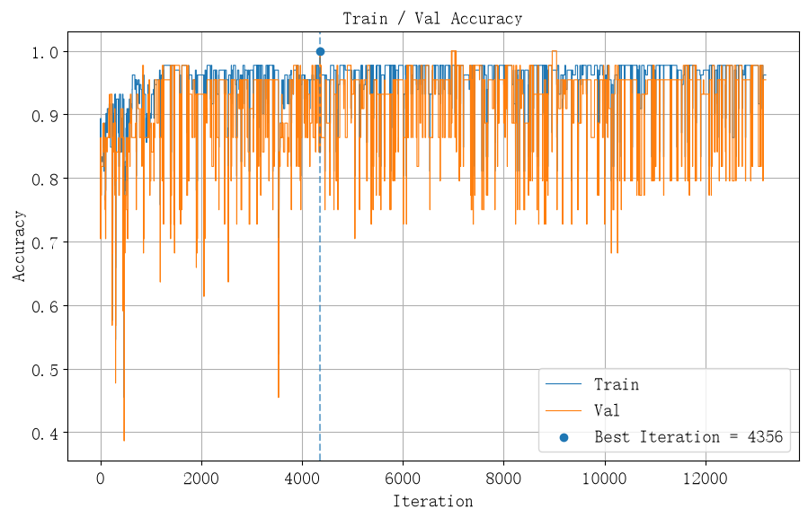

```python
iterations = np.arange(1, len(train_acc) + 1)

fig, ax = plt.subplots(figsize=(10, 6))
ax.plot(iterations, train_acc, label="Train", linewidth=0.8)
ax.plot(iterations, val_acc, label="Val", linewidth=0.8)
ax.scatter(
    best_iteration,
    val_acc[best_iteration - 1],
    zorder=3,
    label=f"Best Iteration = {best_iteration}"
)

ax.axvline(best_iteration, linestyle="--", alpha=0.6)
ax.set(
    xlabel="Iteration",
    ylabel="Accuracy",
    title="Train / Val Accuracy"
)
ax.grid(True)
ax.legend()
display_inline(fig)
```

从训练曲线可以看出，在训练初期，Train Acc 和 Val Acc 整体上呈现上升趋势，说明模型逐渐学习到了数据的分类规律.

但两条曲线均存在明显的波动，特别是 Val Acc，在某些 Iteration 会出现较大幅度的下降. 这是因为感知机采用单样本更新，每次只根据当前样本的分类结果调整参数. 一次更新虽然可能修正当前样本的分类错误，但也可能使原本正确分类的其他样本被错误分类，因此整体 Acc 不一定单调增加.

我们选取 Val Acc 最优的情况，绘制分类边界：

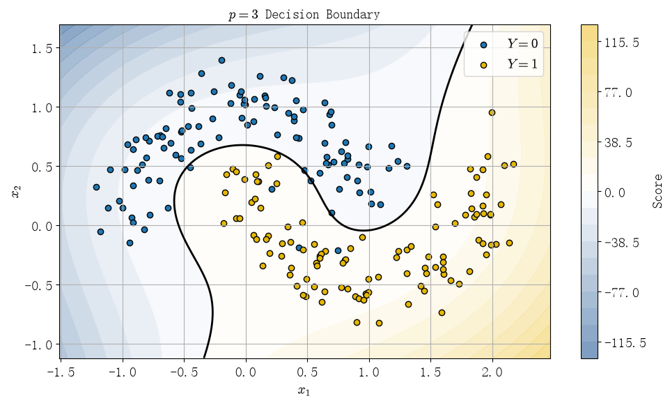

```python
cmap = mpl.colors.LinearSegmentedColormap.from_list(
    "blue_white_yellow",
    ["#4C78A8", "white", "#F2CF5B"]
)


def plot_decision_boundary(X, y, w, b, p, feature_mean, feature_std, title):
    x1 = np.linspace(X[:, 0].min() - 0.3, X[:, 0].max() + 0.3, 400)
    x2 = np.linspace(X[:, 1].min() - 0.3, X[:, 1].max() + 0.3, 400)
    xx1, xx2 = np.meshgrid(x1, x2)
    X_grid = np.column_stack((xx1.ravel(), xx2.ravel()))

    Phi_grid = polynomial_features(X_grid, p)
    Phi_grid = (Phi_grid - feature_mean) / feature_std
    score_grid = (Phi_grid @ w + b).reshape(xx1.shape)

    fig, ax = plt.subplots(figsize=(10, 6))
    vmax = max(np.max(np.abs(score_grid)), 1e-12)
    contour = ax.contourf(
        xx1, xx2, score_grid,
        levels=np.linspace(-vmax, vmax, 21),
        cmap=cmap,
        vmin=-vmax,
        vmax=vmax,
        alpha=0.75
    )

    ax.contour(
        xx1, xx2, score_grid,
        levels=[0],
        colors="black",
        linewidths=2
    )

    ax.scatter(
        X[y == 0, 0], X[y == 0, 1],
        c="C0",
        edgecolors="black",
        label="$Y=0$"
    )

    ax.scatter(
        X[y == 1, 0], X[y == 1, 1],
        c="#E6B800",
        edgecolors="black",
        label="$Y=1$"
    )

    fig.colorbar(contour, ax=ax, label="Score")

    ax.set_xlabel(r"$x_1$")
    ax.set_ylabel(r"$x_2$")
    ax.set_title(title)
    ax.grid(True)
    ax.legend()

    display_inline(fig)


w_p3, b_p3 = w.copy(), b
feature_mean_p3 = feature_mean.copy()
feature_std_p3 = feature_std.copy()

plot_decision_boundary(X, y, w_p3, b_p3, 3, feature_mean_p3, feature_std_p3,
    "$p=3$ Decision Boundary"
)
```

可见，此时，我们的分类边界基本能正确分类出我们的数据.

### 多项式阶数扫描

前面我们人为选取多项式阶数为 $3$，现在我们扫描多项式阶数，固定训练轮数为 $100$ Epoch，扫描

$$ p=1,2,\ldots,10 $$

对于每个多项式阶数，重新进行 Feature Mapping、特征标准化和感知机训练. 不同阶数使用相同的随机种子和样本排列顺序.

```python
@nb.njit(parallel=True)
def scan_polynomial_degree(
    X_train, t_train, X_val, t_val, X_test, p_values, sample_orders
):
    n = p_values.size
    train_acc_best = np.empty(n)
    val_acc_best = np.empty(n)
    best_iteration = np.empty(n)

    for k in nb.prange(n):
        p = p_values[k]

        Phi_train = polynomial_features(X_train, p)
        Phi_val = polynomial_features(X_val, p)
        Phi_test = polynomial_features(X_test, p)

        Phi_train, Phi_val, Phi_test, _, _ = standardize_data(
            Phi_train, Phi_val, Phi_test
        )

        _, _, train_acc, val_acc, iteration = train_perceptron(
            Phi_train, t_train, Phi_val, t_val, sample_orders
        )

        train_acc_best[k] = train_acc[iteration - 1]
        val_acc_best[k] = val_acc[iteration - 1]
        best_iteration[k] = iteration
    return train_acc_best, val_acc_best, best_iteration
```

```python
p_values = np.arange(1, 11)
t_start = time.time()
print("开始扫描...")
train_acc_p, val_acc_p, best_iteration_p = scan_polynomial_degree(
    X_train, t_train, X_val, t_val, X_test, p_values, sample_orders
)
print(f"结束，耗时 {time.time()-t_start:.3f} s")
```

```
开始扫描...
结束，耗时 7.746 s
```

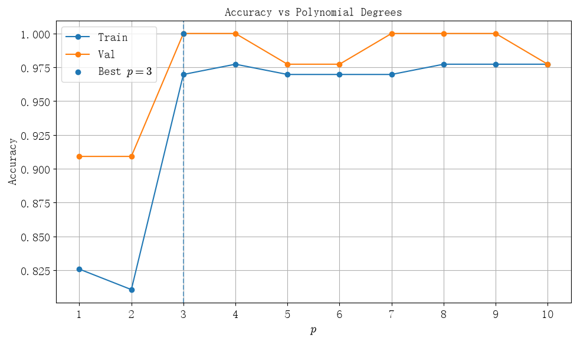

```python
best_index = np.argmax(val_acc_p)
best_p = int(p_values[best_index])
best_val_acc = val_acc_p[best_index]

fig, ax = plt.subplots(figsize=(10, 6))
ax.plot(p_values, train_acc_p, marker="o", label="Train")
ax.plot(p_values, val_acc_p, marker="o", label="Val")
ax.scatter(
    best_p, best_val_acc,
    zorder=3, label=fr"Best $p={best_p}$"
)
ax.axvline(best_p, linestyle="--", alpha=0.6)
ax.set_xlabel("$p$")
ax.set_ylabel("Accuracy")
ax.set_title("Accuracy vs Polynomial Degrees")
ax.set_xticks(p_values)
ax.grid(True)
ax.legend()
display_inline(fig)
```

从不同多项式阶数的 Accuracy 曲线可以看到，当 $p=1,2$ 时，模型的 Train Acc 和 Val Acc 均相对较低，说明低阶多项式特征不足以充分描述 Moon 数据集的非线性分类边界.

当多项式阶数增加到 $p=3$ 时，模型的分类性能明显提升，Val Acc 达到 $1$. 这说明三阶多项式已经能够较好地表达数据的非线性分类结构.

综合考虑验证集准确率和模型复杂度，最终选择 $p=3$ 作为最优多项式阶数.

### 最优模型

我们使用前面扫描得到的最优 $p$，重新训练最优模型，并绘制分类边界.

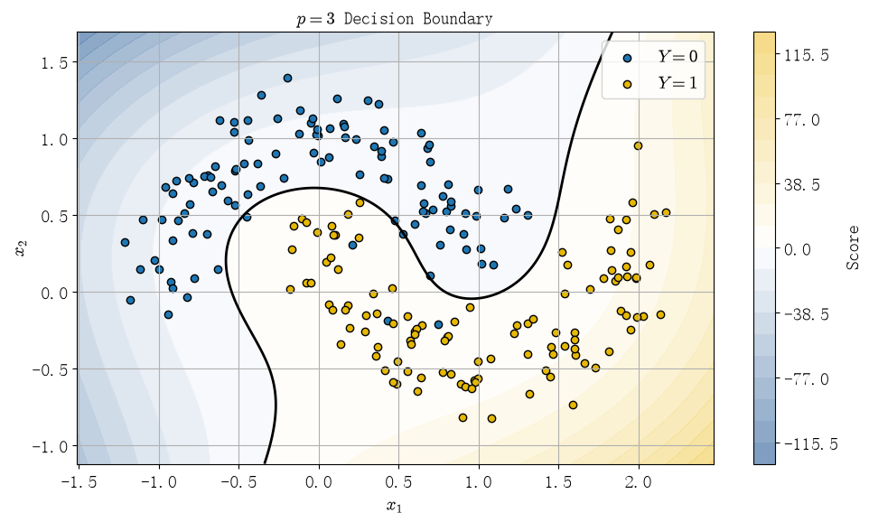

```python
Phi_train_best = polynomial_features(X_train, best_p)
Phi_val_best = polynomial_features(X_val, best_p)
Phi_test_best = polynomial_features(X_test, best_p)

Phi_train_best, Phi_val_best, Phi_test_best, \
feature_mean_best, feature_std_best = standardize_data(
    Phi_train_best,
    Phi_val_best,
    Phi_test_best
)

w_best, b_best, train_acc_best, val_acc_best, \
best_iteration_best = train_perceptron(
    Phi_train_best, t_train,
    Phi_val_best, t_val,
    sample_orders
)

plot_decision_boundary(
    X, y,
    w_best, b_best,
    best_p,
    feature_mean_best,
    feature_std_best,
    fr"$p={best_p}$ Decision Boundary"
)
```

m此时，我们的分类边界基本能正确分类出我们的数据.

我们进一步在 Test 上计算我们的最优模型的 Acc，有：

```python
print(f"Best p: {best_p}")
print(f"Best Iteration: {best_iteration_best}")
for name, Phi, t in [
    ("Train", Phi_train_best, t_train),
    ("Val", Phi_val_best, t_val),
    ("Test", Phi_test_best, t_test)
]:
    acc = perceptron_accuracy(Phi, t, w_best, b_best)
    print(f"{name} Accuracy: {acc:.4f}")
```

```
Best p: 3
Best Iteration: 4356
Train Accuracy: 0.9697
Val Accuracy: 1.0000
Test Accuracy: 0.9773
```

可见，最优模型在 Test 上的 Acc 为 0.9773，此时模型的混淆矩阵为：

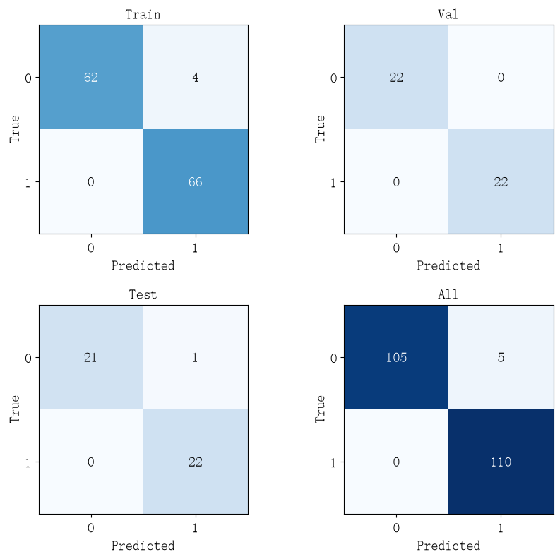

```python
@nb.njit
def predict_perceptron(Phi, w, b):
    score = Phi @ w + b
    return (score >= 0).astype(np.int64)

@nb.njit
def confusion_matrix(y, y_pred):
    TN = np.sum((y == 0) & (y_pred == 0))
    FP = np.sum((y == 0) & (y_pred == 1))
    FN = np.sum((y == 1) & (y_pred == 0))
    TP = np.sum((y == 1) & (y_pred == 1))

    return np.array([
        [TN, FP],
        [FN, TP]
    ])

y_pred_train = predict_perceptron(Phi_train_best, w_best, b_best)
y_pred_val = predict_perceptron(Phi_val_best, w_best, b_best)
y_pred_test = predict_perceptron(Phi_test_best, w_best, b_best)

y_all = np.concatenate((y_train, y_val, y_test))
y_pred_all = np.concatenate((y_pred_train, y_pred_val, y_pred_test))

confusion_train = confusion_matrix(y_train, y_pred_train)
confusion_val = confusion_matrix(y_val, y_pred_val)
confusion_test = confusion_matrix(y_test, y_pred_test)
confusion_all = confusion_matrix(y_all, y_pred_all)
confusion_list = [
    confusion_train, confusion_val,
    confusion_test, confusion_all
]
title_list = ["Train", "Val", "Test", "All"]

vmax = max(confusion.max() for confusion in confusion_list)
fig, axes = plt.subplots(2, 2, figsize=(10, 9))
for ax, confusion, title in zip(axes.flat, confusion_list, title_list):
    im = ax.imshow(confusion, cmap="Blues", vmin=0, vmax=vmax)
    for i in range(2):
        for j in range(2):
            ax.text(
                j, i, str(confusion[i, j]),
                ha="center",
                va="center",
                color="white" if confusion[i, j] > vmax / 2 else "black"
            )
    ax.set_xticks([0, 1])
    ax.set_yticks([0, 1])
    ax.set_xticklabels(["0", "1"])
    ax.set_yticklabels(["0", "1"])
    ax.set_xlabel("Predicted")
    ax.set_ylabel("True")
    ax.set_title(title)
display_inline(fig)
```

从混淆矩阵可以看到，模型在训练集、验证集和测试集上均取得了较好的分类效果. 出现的错误分类基本是噪声带来的影响，整体而言，三阶多项式的感知机已经能较好描述 Moon 数据集的结构.

## 核方法

### 特征标准化

前面我们采用多项式 Feature Mapping，将二维输入映射到更高维的特征空间，再使用感知机进行分类. 但是，随着多项式阶数增加，特征空间的维数也随之增加，需要显式构造更多特征.

核方法通过核函数直接计算两个样本在特征空间中的内积，而不需要显式构造特征映射：

$$ K(\mathbf x_i,\mathbf x_j)=\boldsymbol\phi(\mathbf x_i)^{\mathsf T} \boldsymbol\phi(\mathbf x_j) $$

这里我们使用 RBF 核函数：

$$ K_\gamma(\mathbf x_i,\mathbf x_j)=\exp\left(-\gamma\|\mathbf x_i-\mathbf x_j\|^2\right) $$

其中 $\gamma>0$ 为核函数的超参数.

- 当 $\gamma$ 较小时，样本之间的相互影响范围较大，分类边界通常比较平滑.
- 当 $\gamma$ 较大时，每个样本的影响更加局部，模型能够形成更加复杂的分类边界，但也更容易受到噪声影响.

为避免两个输入特征的数值尺度影响核函数中的距离计算，我们首先对原始输入特征进行标准化.

```python
X_train_kernel, X_val_kernel, X_test_kernel, kernel_mean, kernel_std = standardize_data(X_train, X_val, X_test)
```

### 模型定义

对于包含 $m$ 个训练样本的数据集，我们构造核矩阵：

$$ \mathbf K_{\mathrm{train}}= \begin{pmatrix} K(\mathbf x_1,\mathbf x_1)&\cdots&K(\mathbf x_1,\mathbf x_m)\\ \vdots&\ddots&\vdots\\ K(\mathbf x_m,\mathbf x_1)&\cdots&K(\mathbf x_m,\mathbf x_m) \end{pmatrix} $$

核感知机的决策函数可以写为：

$$ s(\mathbf x)=\sum_{i=1}^{m}\alpha_iK_\gamma(\mathbf x_i,\mathbf x)+b $$

其中 $\alpha_i$ 为权重，$b$ 为偏置. 预测结果为：

$$ \hat t= \begin{cases} 1,&s(\mathbf x)\geq0\\ -1,&s(\mathbf x)<0 \end{cases} $$

对于第 $i$ 个训练样本，仍然使用与前面相同的感知机更新规则：

$$ \begin{aligned} \alpha_i^{\mathrm{new}}&=\alpha_i^{\mathrm{old}}+\frac12(t_i-\hat t_i)\\ b^{\mathrm{new}}&=b^{\mathrm{old}}+\frac12(t_i-\hat t_i) \end{aligned} $$

```python
@nb.njit
def rbf_kernel(A, B, gamma):
    m, n = A.shape[0], B.shape[0]
    K = np.empty((m, n), dtype=np.float64)
    for i in nb.prange(m):
        for j in range(n):
            d2 = 0.0
            for k in range(A.shape[1]):
                diff = A[i, k] - B[j, k]
                d2 += diff * diff
            K[i, j] = np.exp(-gamma * d2)
    return K
```

### 模型训练

本实验采用随机顺序的单样本核感知机算法. 与前面的多项式方法相同，每个 Epoch 开始时打乱训练样本顺序，然后依次进行预测和参数更新.

这里先取 $\gamma=1$，训练 $100$ 个 Epoch. 每次 Iteration 后计算 Train Acc 和 Val Acc，并保存 Val Acc 最高时的模型参数.

为了提高训练效率，我们在每次参数更新时直接更新全部样本的预测分数. 考虑任意一个训练样本 $\mathbf{x}_k$，其更新后的预测分数为：

$$ \begin{aligned} s^{\mathrm{new}}(\mathbf x_k) &=(\mathbf w^{\mathrm{new}})^\top \Phi(\mathbf x_k)+b^{\mathrm{new}}\\ &=(\mathbf w^{\mathrm{old}}+\delta_i\Phi(\mathbf x_i))^\top \Phi(\mathbf x_k) +b^{\mathrm{old}}+\delta_i\\ &=\underbrace{(\mathbf w^{\mathrm{old}})^\top\Phi(\mathbf x_k) +b^{\mathrm{old}}}_{s^{\mathrm{old}}(\mathbf x_k)} +\delta_i\Phi(\mathbf x_i)^\top\Phi(\mathbf x_k) +\delta_i \end{aligned} $$

其中：

$$ \delta_i = \frac12(t_i-\hat t_i) $$

利用核函数定义，得到

$$ s^{\mathrm{new}}(\mathbf x_k) =s^{\mathrm{old}}(\mathbf x_k) +\delta_i[K_\gamma(\mathbf x_i,\mathbf x_k)+1] $$

从而每一个样本的预测分数更新不需要重新计算求和.

```python
gamma = 1.0
K_train = rbf_kernel(X_train_kernel, X_train_kernel, gamma)
K_val = rbf_kernel(X_val_kernel, X_train_kernel, gamma)


@nb.njit
def train_kernel_perceptron(K_train, t_train, K_val, t_val, sample_orders):
    epochs, m = sample_orders.shape
    n_iterations = epochs * m
    alpha = np.zeros(m, dtype=np.float64)
    b = 0.0
    scores_train = np.zeros(m, dtype=np.float64)
    scores_val = np.zeros(t_val.shape[0], dtype=np.float64)
    train_acc = np.empty(n_iterations, dtype=np.float64)
    val_acc = np.empty(n_iterations, dtype=np.float64)

    best_alpha = alpha.copy()
    best_b = b
    best_val_acc = -1.0
    best_iteration = 0
    for epoch in range(epochs):
        for j in range(m):
            i = sample_orders[epoch, j]
            t_pred = 1 if scores_train[i] >= 0 else -1
            delta = 0.5 * (t_train[i] - t_pred)
            if delta != 0:
                alpha[i] += delta
                b += delta
                for k in range(m):
                    scores_train[k] += delta * (K_train[k, i] + 1.0)
                for k in range(t_val.shape[0]):
                    scores_val[k] += delta * (K_val[k, i] + 1.0)
            iteration = epoch * m + j
            correct_train = 0
            for k in range(m):
                pred = 1 if scores_train[k] >= 0 else -1
                if pred == t_train[k]:
                    correct_train += 1
            correct_val = 0
            for k in range(t_val.shape[0]):
                pred = 1 if scores_val[k] >= 0 else -1
                if pred == t_val[k]:
                    correct_val += 1
            train_acc[iteration] = correct_train / m
            val_acc[iteration] = correct_val / t_val.shape[0]
            if val_acc[iteration] > best_val_acc:
                best_val_acc = val_acc[iteration]
                best_iteration = iteration + 1
                best_alpha = alpha.copy()
                best_b = b
    return best_alpha, best_b, train_acc, val_acc, best_iteration
```

```python
print("开始训练...")
t_start = time.time()
alpha_kernel, b_kernel, train_acc_kernel, val_acc_kernel, best_iteration_kernel = train_kernel_perceptron(
    K_train, t_train, K_val, t_val, sample_orders
)

print(f"结束，耗时 {time.time() - t_start:.3f} s")
```

```
开始训练...
结束，耗时 2.491 s
```

绘制 Train Acc 和 Val Acc 随训练参数更新次数的变化.

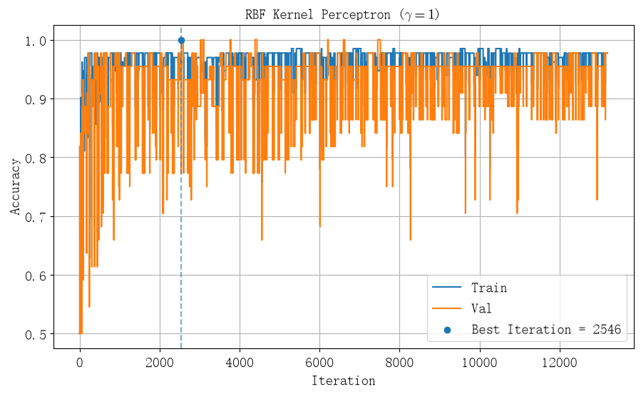

```python
iterations_kernel = np.arange(1, len(train_acc_kernel) + 1)
fig, ax = plt.subplots(figsize=(10, 6))
ax.plot(iterations_kernel, train_acc_kernel, label="Train")
ax.plot(iterations_kernel, val_acc_kernel, label="Val")

ax.scatter(
    best_iteration_kernel,
    val_acc_kernel[best_iteration_kernel - 1],
    zorder=3,
    label=f"Best Iteration = {best_iteration_kernel}"
)

ax.axvline(
    best_iteration_kernel,
    linestyle="--", alpha=0.6
)

ax.set(
    xlabel="Iteration",
    ylabel="Accuracy",
    title=fr"RBF Kernel Perceptron ($\gamma={gamma:g}$)"
)
ax.grid(True)
ax.legend()
display_inline(fig)
```

从训练曲线可以看到，随着训练进行，Train Acc 和 Val Acc 整体上逐渐提高，说明核感知机能够利用 RBF 核函数学习 Moon 数据集的非线性分类结构.

但 Acc 曲线仍然存在明显的波动，这是因为模型采用单样本更新，每次参数变化都可能影响其他样本的分类结果. 因此训练过程中的 Acc 并不保证单调增加.

我们选取 Val Acc 最优的情况，绘制分类边界：

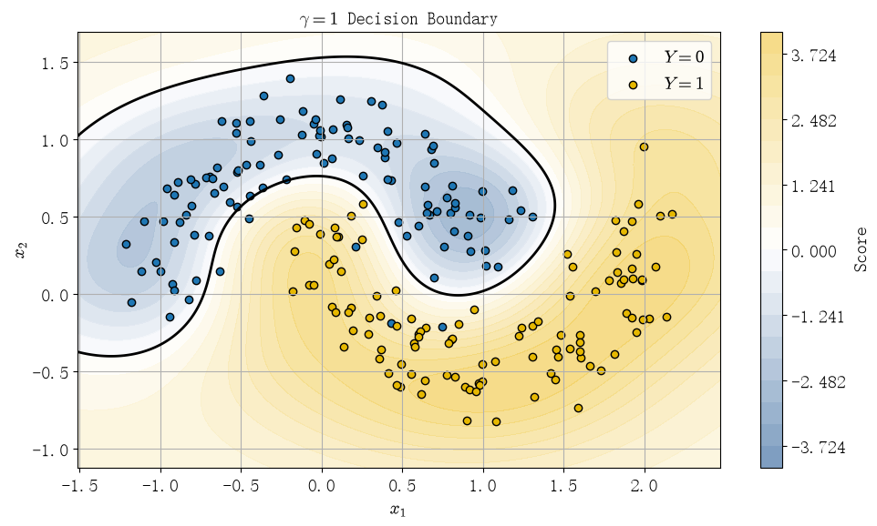

```python
@nb.njit(parallel=True)
def kernel_grid_scores(X_grid, X_train, alpha, b, gamma):
    m = X_grid.shape[0]
    n = X_train.shape[0]
    scores = np.empty(m, dtype=np.float64)
    for i in nb.prange(m):
        score = b
        for j in range(n):
            if alpha[j] == 0:
                continue
            d2 = 0.0
            for k in range(X_grid.shape[1]):
                diff = X_grid[i, k] - X_train[j, k]
                d2 += diff * diff
            score += alpha[j] * np.exp(-gamma * d2)
        scores[i] = score
    return scores


def plot_kernel_decision_boundary(
    X, y, X_train_kernel, alpha, b, gamma, kernel_mean, kernel_std, title
):
    x1 = np.linspace(X[:, 0].min() - 0.3, X[:, 0].max() + 0.3, 400)
    x2 = np.linspace(X[:, 1].min() - 0.3, X[:, 1].max() + 0.3, 400)

    xx1, xx2 = np.meshgrid(x1, x2)
    X_grid = np.column_stack((xx1.ravel(), xx2.ravel()))
    X_grid_std = (X_grid - kernel_mean) / kernel_std

    score_grid = kernel_grid_scores(
        X_grid_std, X_train_kernel, alpha, b, gamma
    ).reshape(xx1.shape)

    fig, ax = plt.subplots(figsize=(10, 6))
    vmax = max(np.max(np.abs(score_grid)), 1e-12)

    contour = ax.contourf(
        xx1, xx2, score_grid,
        levels=np.linspace(-vmax, vmax, 21),
        cmap=cmap,
        vmin=-vmax,
        vmax=vmax,
        alpha=0.75
    )

    ax.contour(
        xx1, xx2, score_grid,
        levels=[0],
        colors="black",
        linewidths=2
    )

    ax.scatter(
        X[y == 0, 0], X[y == 0, 1],
        c="C0", edgecolors="black",
        label="$Y=0$"
    )

    ax.scatter(
        X[y == 1, 0], X[y == 1, 1],
        c="#E6B800", edgecolors="black",
        label="$Y=1$"
    )

    fig.colorbar(contour, ax=ax, label="Score")

    ax.set_xlabel(r"$x_1$")
    ax.set_ylabel(r"$x_2$")
    ax.set_title(title)
    ax.grid(True)
    ax.legend()

    display_inline(fig)


plot_kernel_decision_boundary(
    X, y,
    X_train_kernel, alpha_kernel, b_kernel,
    gamma, kernel_mean, kernel_std,
    fr"$\gamma={gamma:g}$ Decision Boundary"
)
```

可以看出，RBF 核感知机能够形成非线性的分类边界，从而较好地分离 Moon 数据集中的两类样本.

与多项式方法不同，RBF 核函数没有显式指定多项式阶数，而是受到核参数 $\gamma$ 以及训练样本分布的影响. 下面我们扫描不同的 $\gamma$，研究核函数尺度对分类性能的影响.

### Gamma 扫描

前面我们选取 $\gamma=1$，现在扫描不同的 Gamma，固定训练轮数为 $100$ Epoch，扫描：

$$ 10^{-2} < \gamma < 10^2 $$

对于每个 Gamma，重新计算 RBF 核矩阵，并从零开始训练核感知机. 不同 Gamma 使用相同的样本排列顺序，以保证比较的公平性.

对于每个 Gamma，记录 Val Acc 最高时对应的 Train Acc、Val Acc 以及 Iteration. 最终根据验证集准确率选择最优 Gamma.

```python
@nb.njit(parallel=True)
def scan_gamma(X_train, X_val, t_train, t_val, gamma_values, sample_orders):
    n = gamma_values.size
    train_acc_best = np.empty(n)
    val_acc_best = np.empty(n)
    best_iteration = np.empty(n)
    for k in nb.prange(n):
        gamma = gamma_values[k]
        K_train = rbf_kernel(X_train, X_train, gamma)
        K_val = rbf_kernel(X_val, X_train, gamma)
        _, _, train_acc, val_acc, iteration = train_kernel_perceptron(
            K_train, t_train, K_val, t_val, sample_orders
        )
        train_acc_best[k] = train_acc[iteration - 1]
        val_acc_best[k] = val_acc[iteration - 1]
        best_iteration[k] = iteration
    return train_acc_best, val_acc_best, best_iteration
```

```python
gamma_values = np.logspace(-2, 2, 20)
print("开始扫描...")
t_start = time.time()
train_acc_gamma, val_acc_gamma, best_iteration_gamma = scan_gamma(
    X_train_kernel, X_val_kernel, t_train, t_val, gamma_values, sample_orders
)
print(f"结束，耗时 {time.time() - t_start:.3f} s")
```

```
开始扫描...
结束，耗时 3.949 s
```

绘制不同 Gamma 对应的 Train Acc 和 Val Acc，观察核参数对分类性能的影响.

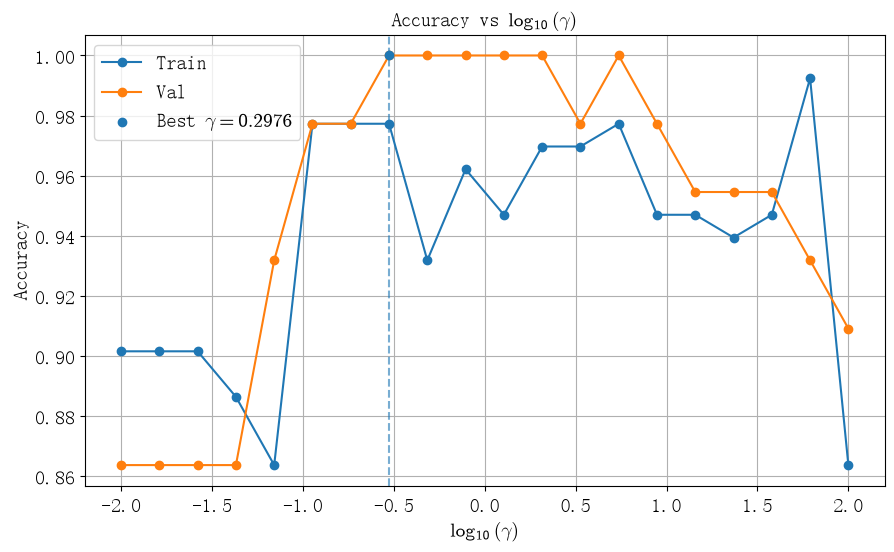

```python
best_index_kernel = np.argmax(val_acc_gamma)
best_gamma = gamma_values[best_index_kernel]
best_val_acc_kernel = val_acc_gamma[best_index_kernel]

log_gamma_values = np.log10(gamma_values)
best_log_gamma = np.log10(best_gamma)

fig, ax = plt.subplots(figsize=(10, 6))

ax.plot(
    log_gamma_values, train_acc_gamma,
    marker="o", label="Train"
)
ax.plot(
    log_gamma_values, val_acc_gamma,
    marker="o", label="Val"
)

ax.scatter(
    best_log_gamma, best_val_acc_kernel,
    zorder=3,
    label=fr"Best $\gamma={best_gamma:.4g}$"
)

ax.axvline(
    best_log_gamma,
    linestyle="--", alpha=0.6
)

ax.set_xlabel(r"$\log_{10}(\gamma)$")
ax.set_ylabel("Accuracy")
ax.set_title(r"Accuracy vs $\log_{10}(\gamma)$")
ax.grid(True)
ax.legend()

display_inline(fig)
```

当 Gamma 较小时，模型难以区分局部的数据结构，出现欠拟合.

随着 Gamma 增加，模型能够更加准确地描述 Moon 数据集中的非线性分类边界，Train Acc 和 Val Acc 整体得到改善.

当 Gamma 进一步增大时，模型容易过度依赖个别训练样本，导致验证集准确率下降.

大体而言 Acc 呈现 “欠拟合-过拟合” 的过程.

### 最优模型

我们使用前面扫描得到的最优 Gamma，重新计算核矩阵并训练核感知机，随后绘制其分类边界.

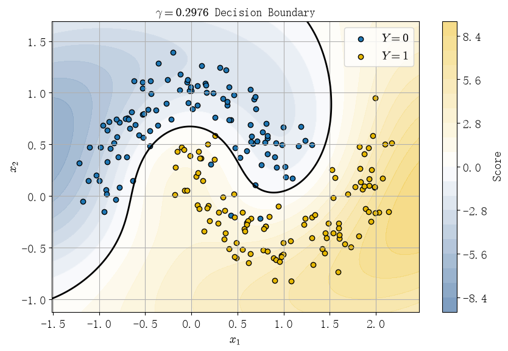

```python
K_train_best_kernel = rbf_kernel(X_train_kernel, X_train_kernel, best_gamma)
K_val_best_kernel = rbf_kernel(X_val_kernel, X_train_kernel, best_gamma)
K_test_best_kernel = rbf_kernel(X_test_kernel, X_train_kernel, best_gamma)

alpha_kernel_best, b_kernel_best, train_acc_kernel_best, val_acc_kernel_best, best_iteration_kernel_best = train_kernel_perceptron(
    K_train_best_kernel, t_train,
    K_val_best_kernel, t_val,
    sample_orders
)

plot_kernel_decision_boundary(
    X, y, X_train_kernel, alpha_kernel_best, b_kernel_best, best_gamma,
    kernel_mean, kernel_std,
    fr"$\gamma={best_gamma:.4g}$ Decision Boundary"
)
```

可以看出，最优核感知机能够形成与 Moon 数据集分布相符的非线性分类边界，两类样本基本被正确分离.

进一步计算最优模型在 Train、Val 和 Test 上的 Accuracy.

```python
@nb.njit
def predict_kernel_perceptron(K, alpha, b):
    scores = K @ alpha + b
    return (scores >= 0).astype(np.int64)


print(f"Best Gamma: {best_gamma:.6f}")
print(f"Best Iteration: {best_iteration_kernel_best}")

for name, K, t in [
    ("Train", K_train_best_kernel, t_train),
    ("Val", K_val_best_kernel, t_val),
    ("Test", K_test_best_kernel, t_test)
]:
    y_pred = predict_kernel_perceptron(
        K, alpha_kernel_best, b_kernel_best
    )
    acc = np.mean(y_pred == (t + 1) // 2)
    print(f"{name} Accuracy: {acc:.4f}")
```

```
Best Gamma: 0.297635
Best Iteration: 9876
Train Accuracy: 0.9773
Val Accuracy: 1.0000
Test Accuracy: 1.0000
```

可以看到，最优核感知机在 Test 上的 Accuracy 为 $1.0000$，即全部 $44$ 个测试样本均被正确分类.

为了进一步观察不同类别的分类情况，我们分别计算 Train、Val、Test 和 All 的混淆矩阵

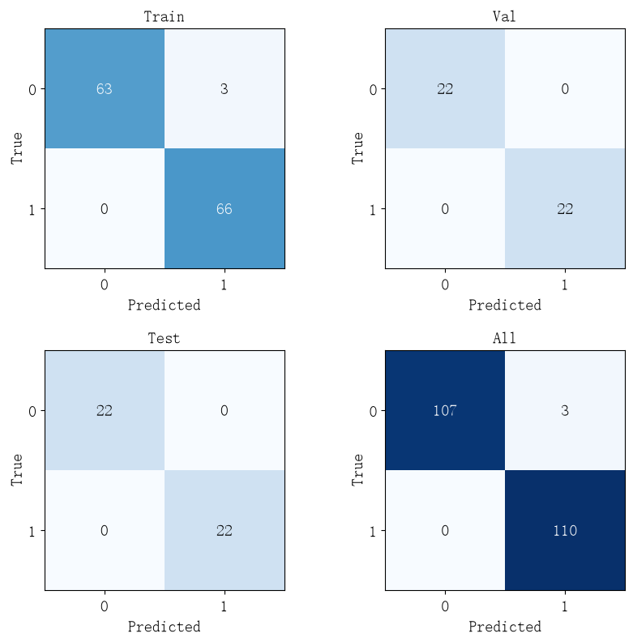

```python
y_pred_train_kernel = predict_kernel_perceptron(
    K_train_best_kernel, alpha_kernel_best, b_kernel_best
)
y_pred_val_kernel = predict_kernel_perceptron(
    K_val_best_kernel, alpha_kernel_best, b_kernel_best
)
y_pred_test_kernel = predict_kernel_perceptron(
    K_test_best_kernel, alpha_kernel_best, b_kernel_best
)

y_all_kernel = np.concatenate((y_train, y_val, y_test))
y_pred_all_kernel = np.concatenate((
    y_pred_train_kernel,
    y_pred_val_kernel,
    y_pred_test_kernel
))

confusion_kernel_train = confusion_matrix(
    y_train, y_pred_train_kernel
)
confusion_kernel_val = confusion_matrix(
    y_val, y_pred_val_kernel
)
confusion_kernel_test = confusion_matrix(
    y_test, y_pred_test_kernel
)
confusion_kernel_all = confusion_matrix(
    y_all_kernel, y_pred_all_kernel
)

confusion_kernel_list = [
    confusion_kernel_train,
    confusion_kernel_val,
    confusion_kernel_test,
    confusion_kernel_all
]
title_list = ["Train", "Val", "Test", "All"]

vmax = max(C.max() for C in confusion_kernel_list)

fig, axes = plt.subplots(2, 2, figsize=(10, 9))

for ax, C, title in zip(
    axes.flat, confusion_kernel_list, title_list
):
    ax.imshow(C, cmap="Blues", vmin=0, vmax=vmax)

    for i in range(2):
        for j in range(2):
            ax.text(
                j, i, str(C[i, j]),
                ha="center",
                va="center",
                color="white" if C[i, j] > vmax / 2 else "black"
            )

    ax.set_xticks([0, 1])
    ax.set_yticks([0, 1])
    ax.set_xticklabels(["0", "1"])
    ax.set_yticklabels(["0", "1"])
    ax.set_xlabel("Predicted")
    ax.set_ylabel("True")
    ax.set_title(title)

display_inline(fig)
```

从混淆矩阵可以看到，最优核感知机在 Train 中有 $3$ 个负类样本被误判为正类，而 Val 和 Test 中均没有错误分类的样本. 在全部 $220$ 个样本中，仅有 $3$ 个样本分类错误.

综上，核感知机能够较好地学习当前数据集的非线性分类规律，并且在测试集上取得了较好的分类效果.

## 结论

本次实验使用感知机算法对 `make_moons` 二分类数据集进行分类. 分别采用多项式 Feature Mapping 和 RBF 核方法实现非线性分类，并研究多项式阶数和核参数 Gamma 对分类性能的影响. 得到如下结论：

## 参考资料以及 AI 使用说明

- 背景补充部分个人写出大体大纲，使用 GPT 6 Astra 生成并进行人工核验和修改.
- 代码编写使用 Deepseek V4 Flash FIM 模式进行补全和生成（尤其是绘图相关函数，基本是直接生成），经过人工核验和运行验证.
- 扫参函数由 GPT 6 生成，经过人工核验和运行验证.
- 文本和公式编写使用 Deepseek V4 Flash FIM 模式进行生成和补全，经过人工核验和修改.

## 致谢

暂无

## 附一：问题

### 随机梯度下降与郎之万方程关系？

在随机梯度下降中，模型使用随机抽取的样本或 Mini-Batch 估计梯度. 因此，参数更新可以写为

$$ \boldsymbol\theta_{k+1}=\boldsymbol\theta_k-\eta\nabla L(\boldsymbol\theta_k)-\eta\boldsymbol\xi_k $$

其中 $\boldsymbol\xi_k$ 为随机梯度相对于完整梯度的偏差. 这一形式与统计物理中的过阻尼朗之万方程具有一定的相似性：

$$ \frac{\mathrm d\mathbf x}{\mathrm dt}=-\mu\nabla U(\mathbf x)+\boldsymbol\xi(t) $$

那么，是否可以将随机梯度下降视为一种随机动力学过程？进一步地，朗之万方程中的耗散与随机涨落在热平衡条件下满足涨落耗散关系. SGD 中是否也存在类似的关系？

但上述类比存在一定的问题，在随机梯度下降中，相对完整梯度的偏差 $\boldsymbol \xi_k$ 不一定在各个方向上是独立，也不一定是 Gauss 分布，这种类比可能不一定能在感知机 or 神经网络中使用.

### 随机梯度下降过程中的波动与 Loss 函数或模型的某些性质的关系？

在随机梯度下降的训练过程中，训练 Loss 存在波动，这些波动是否包含关于 Loss 函数局部几何结构的信息？例如，是否可以利用参数波动的方差等参数，研究 Loss 曲面的曲率等性质？是否有可能能给出一定的定量关系？

## 附二：学习心得

暂无